# DATA 606 Data Project Proposal

Calvin Wong

```
##                              Category
## 1 Industrial Arts & Consumer Services
## 2                                Arts
## 3                            Business
## 4 Industrial Arts & Consumer Services
## 5             Computers & Mathematics
## 6                 Law & Public Policy
##                                    Major Total Employed Fulltime
## 1                  CONSTRUCTION SERVICES  9173     7098     6511
## 2      COMMERCIAL ART AND GRAPHIC DESIGN 53864    40492    29553
## 3                 HOSPITALITY MANAGEMENT 24417    18368    14784
## 4 COSMETOLOGY SERVICES AND CULINARY ARTS  5411     3590     2701
## 5             COMMUNICATION TECHNOLOGIES  9109     7512     5622
## 6                        COURT REPORTING  1542     1008      860
##   Median_salary
## 1         75000
## 2         60000
## 3         65000
## 4         47000
## 5         57000
## 6         75000
```

### Part 1 - Introduction

How monetarily viable are graduate degree types against each other?

In fall 2016, total undergraduate enrollment in degree-granting post secondary institutions was 16.9 million students, an increase of 28 percent from 2000, when enrollment was 13.2 million students. During the same period of time, some 3.0 million students were enrolled in post baccalaureate degree programs. Between 2016 and 2027, both undergraduate and post baccalaureate enrollment is projected to increase by a modest 2-3 percent.

For young adults ages 25–34 who worked full time, higher educational attainment was often associated with higher median earnings. For example, in 2016 the median earnings of young adults with a master’s or higher degree were $64,100, some 28 percent higher than those of young adults with a bachelor’s degree ($50,000). In the same year, the median earnings of young adults with a bachelor’s degree were 57 percent higher than those of young adult high school completed ($31,800). In addition, the median earnings of young adult high school completers were 26 percent higher than those of young adults who did not complete high school ($25,400). This pattern of higher earnings associated with higher levels of educational attainment also held regardless of gender as well as for racial designations.

Georgetown’s ‘The Economic Value of College Majors’ report noted that roughly 80% of today’s incoming college freshmen ultimately choose a major based on potential salary and benefits. The purpose of this analysis is to review an independent data set from the U.S. Census Bureau which provides median salary information across different work categories from 2012. This analysis will assist fellow higher education seekers which career path can yield the highest potential salary.

### Part 2 - Data

#### Data collection

Every year, the U.S. Census Bureau contacts over 3.5 million households across the country to participate in the American Community Survey (ACS). The information that the Census Bureau collects helps to determine how more than $675 billion dollars of federal funding each year is spent on infrastructure and services. Through the ACS, data about jobs and occupations, educational attainment, veterans, whether people own or rent their home, and many other topics are available. The American Community Survey (ACS) Public Use Microdata Sample (PUMS) files are a set of untabulated records about individual people or housing units. The Census Bureau produces the PUMS files so that data users can create custom tables that are not available through pretabulated (or summary) ACS data products.

#### Type of study

This is an observational study

#### Data Source

This data is an excerpt from American Community Survey 2010-2012 Public Use Microdata Series produced by fivethirtyeight.com and located https://github.com/fivethirtyeight/data/blob/master/college-majors/grad-students.csv

Casselman, B. (2014, September 12). The Economic Guide To Picking A College Major. Retrieved October 18, 2018, from https://fivethirtyeight.com/features/the-economic-guide-to-picking-a-college-major/

#### Dependent Variable

Category and it is qualitative.

#### Independent Variable

Major - Major type (Qualitative) Median_salary - Median earnings (Quantitative)

### Part 3 - Exploratory data analysis

Data structure

```r
str(df)
```

```
## 'data.frame':    173 obs. of  6 variables:
##  $ Category     : Factor w/ 16 levels "Agriculture & Natural Resources",..: 11 2 4 11 6 13 4 1 6 5 ...
##  $ Major        : Factor w/ 173 levels "ACCOUNTING","ACTUARIAL SCIENCE",..: 41 29 84 42 31 44 102 6 39 3 ...
##  $ Total        : int  9173 53864 24417 5411 9109 1542 190996 17488 5611 33928 ...
##  $ Employed     : int  7098 40492 18368 3590 7512 1008 151570 13104 4716 28517 ...
##  $ Fulltime     : int  6511 29553 14784 2701 5622 860 123045 11207 3981 22523 ...
##  $ Median_salary: num  75000 60000 65000 47000 57000 75000 80000 67000 85000 60000 ...
```

Data summary

```r
summary(df)
```

```
##                       Category
##  Engineering              :29
##  Education                :16
##  Humanities & Liberal Arts:15
##  Biology & Life Science   :14
##  Business                 :13
##  Health                   :12
##  (Other)                  :74
##                                    Major         Total
##  ACCOUNTING                           :  1   Min.   :   1542
##  ACTUARIAL SCIENCE                    :  1   1st Qu.:  15284
##  ADVERTISING AND PUBLIC RELATIONS     :  1   Median :  37872
##  AEROSPACE ENGINEERING                :  1   Mean   : 127672
##  AGRICULTURAL ECONOMICS               :  1   3rd Qu.: 148255
##  AGRICULTURE PRODUCTION AND MANAGEMENT:  1   Max.   :1184158
##  (Other)                              :167
##     Employed         Fulltime      Median_salary
##  Min.   :  1008   Min.   :   770   Min.   : 47000
##  1st Qu.: 12659   1st Qu.:  9894   1st Qu.: 65000
##  Median : 28930   Median : 22523   Median : 75000
##  Mean   : 94037   Mean   : 72861   Mean   : 76756
##  3rd Qu.:109944   3rd Qu.: 80794   3rd Qu.: 90000
##  Max.   :915341   Max.   :703347   Max.   :135000
##
```

Distribution of Educational Category

We can see which educational categories are represented by majors types. It seems that the engineering type majors are disproportionately represented.

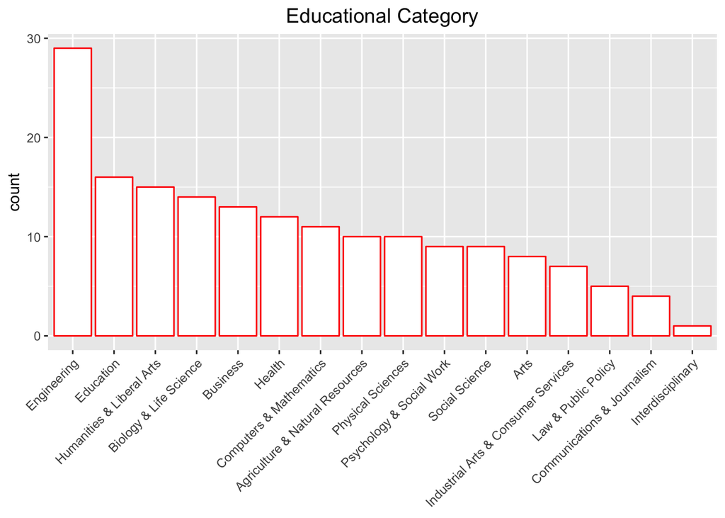

```r
reorder_size <- function(x) {
  factor(x, levels = names(sort(table(x), decreasing = TRUE)))
}

ggplot(df, aes(x=reorder_size(Category))) +
  ggtitle("Educational Category") +
  geom_bar(fill = "white", colour = "red") +
  theme(axis.text.x = element_text(angle = 45, hjust = 1),
        axis.title.x=element_blank(),
        plot.title = element_text(color="black", size=14,hjust = 0.5))
```

Distribution of Salary

The distribution of salary shows a right-skewed distribution. This makes sense because the higher a salary level gets the less amount of job opportunities exists.

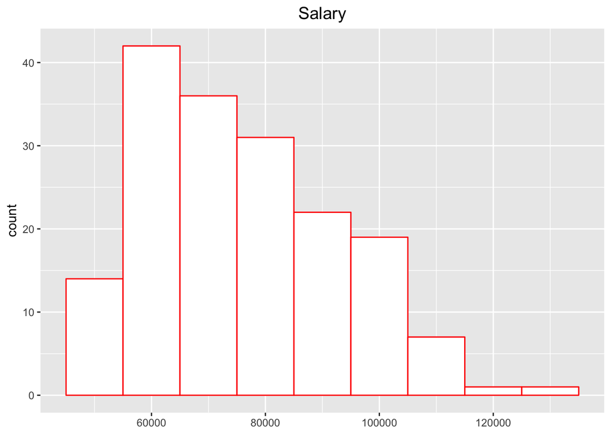

```r
ggplot(df, aes(x=Median_salary)) +
  ggtitle("Salary") +
  geom_histogram(fill = "white", colour = "red",binwidth = 10000) +
  theme(axis.title.x=element_blank(),
        plot.title = element_text(color="black", size=14,hjust = 0.5))
```

We can see which educational categories have the highest median salaries. It seems that STEM-based and business educational categories have the highest median salaries. Based on the study, The Economic Value of College Majors by Georgetown University, STEM and business majors not only have the highest wages, they experience the largest wage growth over the course of their careers. The fact is that college majors play such an enormous role in determining college graduates’ wages and their career trajectory.

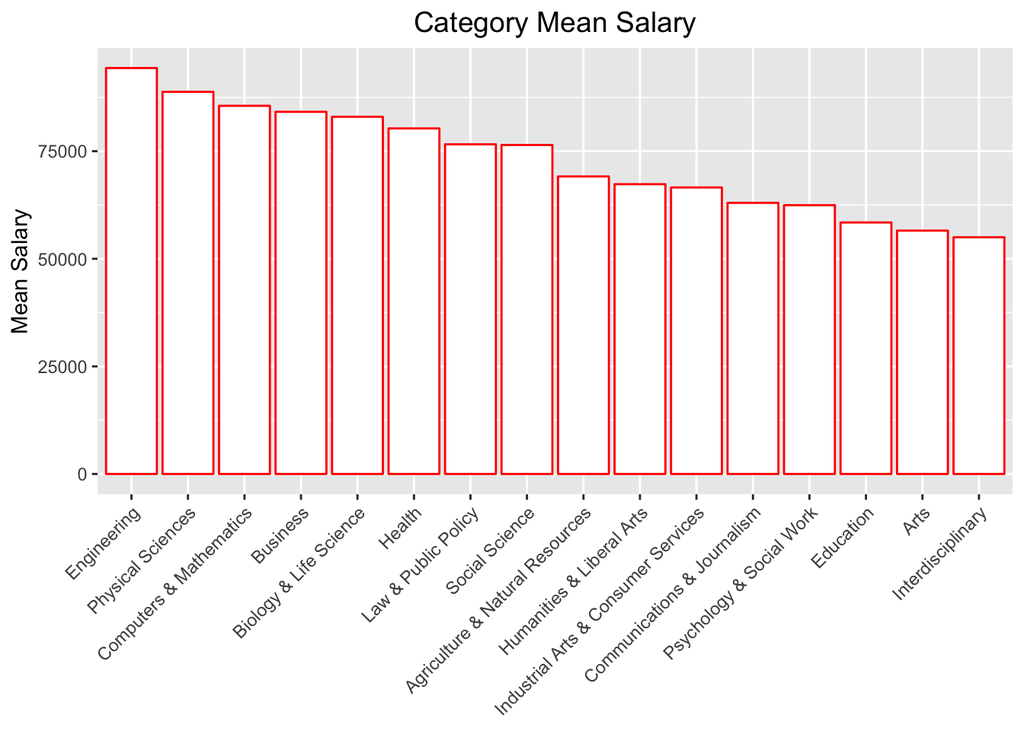

```r
df_mean <- df %>%
  group_by(Category) %>%
  summarise(Median_salary = mean(as.numeric(Median_salary)))

ggplot(df_mean, aes(x= reorder(Category, -Median_salary), y=Median_salary)) +
  ggtitle("Category Mean Salary") +
  geom_bar(stat = "identity", fill = "white", colour = "red") +
  theme(axis.text.x = element_text(angle = 45, hjust = 1),
        axis.title.x = element_blank(),
        plot.title = element_text(color="black", size=14,hjust = 0.5)) +
        labs(y = "Mean Salary")
```

### Part 4 - Inference

#### ANOVA

There are three conditions we must check for an ANOVA analysis: all observations must be independent, the data in each group must be nearly normal, and the variance within each group must be approximately equal.

We believe all conditions are met because the data from each category is independant (it is unlikely salaries from 1 major has any influences on salary for another). We also estimate that while the variability and distributions are not ideal, they should also be adequate for conducting a simple ANOVA test.

Hypothesis test

H0: Category salaries are not different from each other

HA: Category salaries are different from each other

Here I plotted out the variability of the dataset by category.

```r
cat_info <- summarise(group_by(df, Category), mean = round(mean(Median_salary),0), variance = round(var(Median_salary),0), stdev = round(sd(Median_salary), 0))
knitr::kable(cat_info);
```

| Category | mean | variance | stdev |
| --- | --- | --- | --- |
| Agriculture & Natural Resources | 69130 | 51502333 | 7177 |
| Arts | 56544 | 11279598 | 3359 |
| Biology & Life Science | 83000 | 272000000 | 16492 |
| Business | 84154 | 157141026 | 12536 |
| Communications & Journalism | 63000 | 32666667 | 5715 |
| Computers & Mathematics | 85545 | 140672727 | 11861 |
| Education | 58438 | 17329167 | 4163 |
| Engineering | 94328 | 152504926 | 12349 |
| Health | 80292 | 472748106 | 21743 |
| Humanities & Liberal Arts | 67333 | 66952381 | 8182 |
| Industrial Arts & Consumer Services | 66571 | 199285714 | 14117 |
| Interdisciplinary | 55000 | NA | NA |
| Law & Public Policy | 76600 | 58300000 | 7635 |
| Physical Sciences | 88800 | 59733333 | 7729 |
| Psychology & Social Work | 62456 | 89967778 | 9485 |
| Social Science | 76444 | 170277778 | 13049 |

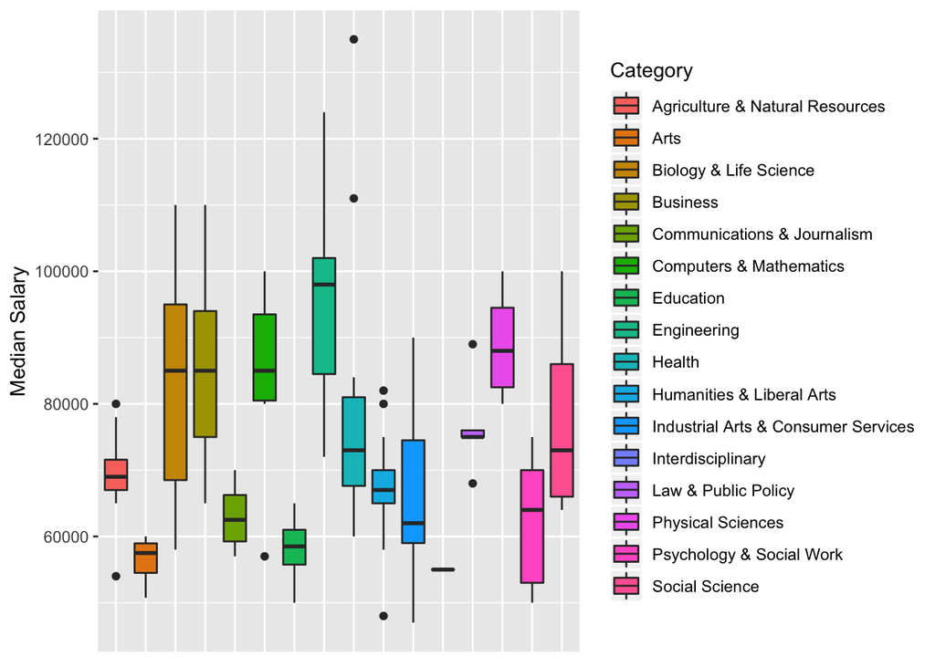

```r
ggplot(df, aes(factor(Category), Median_salary)) +
  geom_boxplot(aes(fill=Category)) +
  xlab("") +
  ylab("Median Salary") +
  theme(axis.title.x=element_blank(),
        axis.text.x=element_blank(),
        axis.ticks.x=element_blank())
```

We can see from our test that the p-value is extremely low at <2e-16. This causes us to reject H0 and conclude that there are differences between educationcal category salaries. However, p-value tests do not paint a clear picture especially considering a multiple variable hypothesis like this one. We will also evaluate our hypothesis through a Tukey HSD Test.

```r
anova <- aov(df$Median_salary ~ df$Category)
summary(anova)
```

```
##              Df    Sum Sq   Mean Sq F value Pr(>F)
## df$Category  15 2.701e+10 1.801e+09   12.74 <2e-16 ***
## Residuals   157 2.219e+10 1.413e+08
## ---
## Signif. codes:  0 '***' 0.001 '**' 0.01 '*' 0.05 '.' 0.1 ' ' 1
```

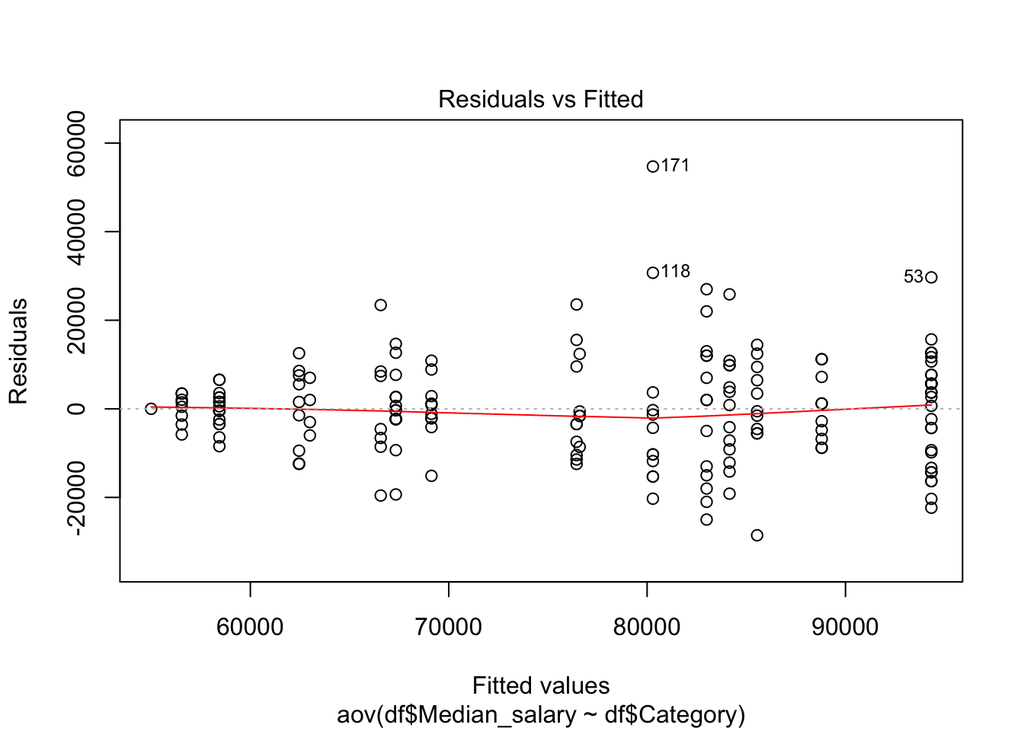

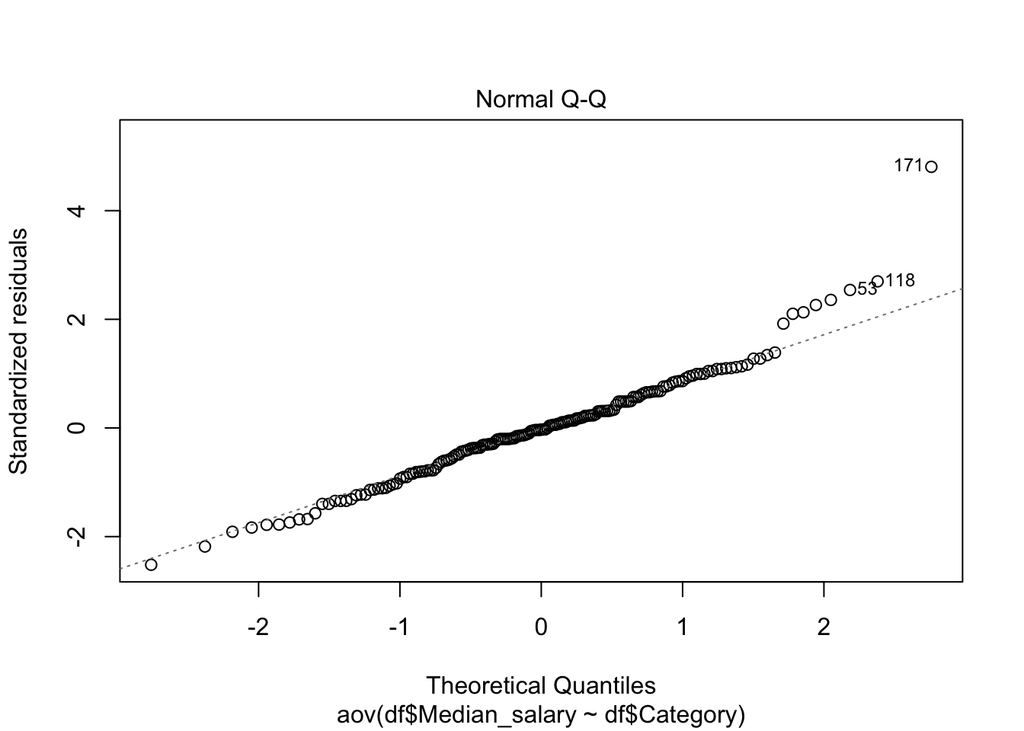

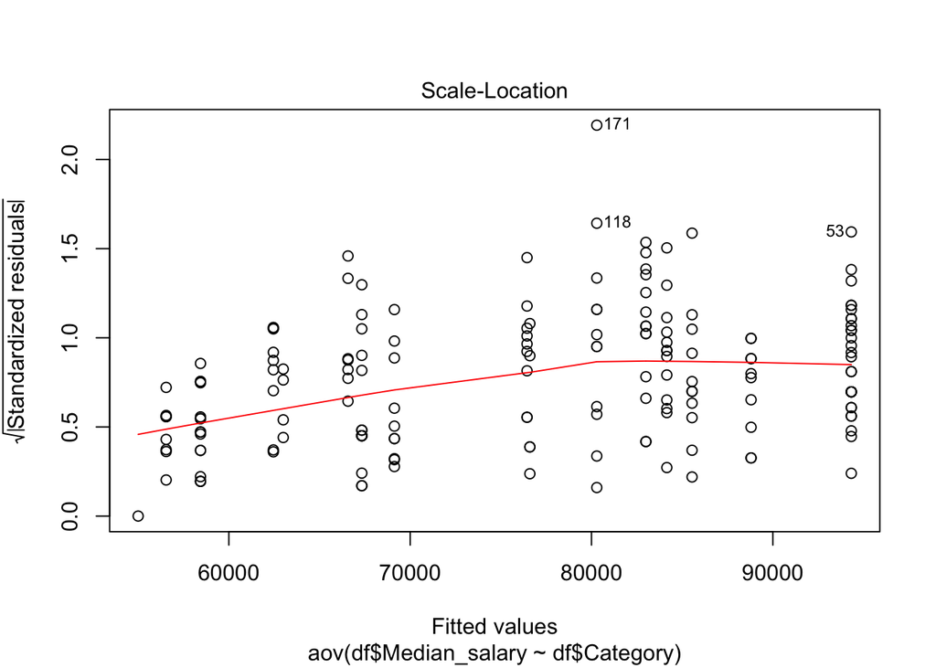

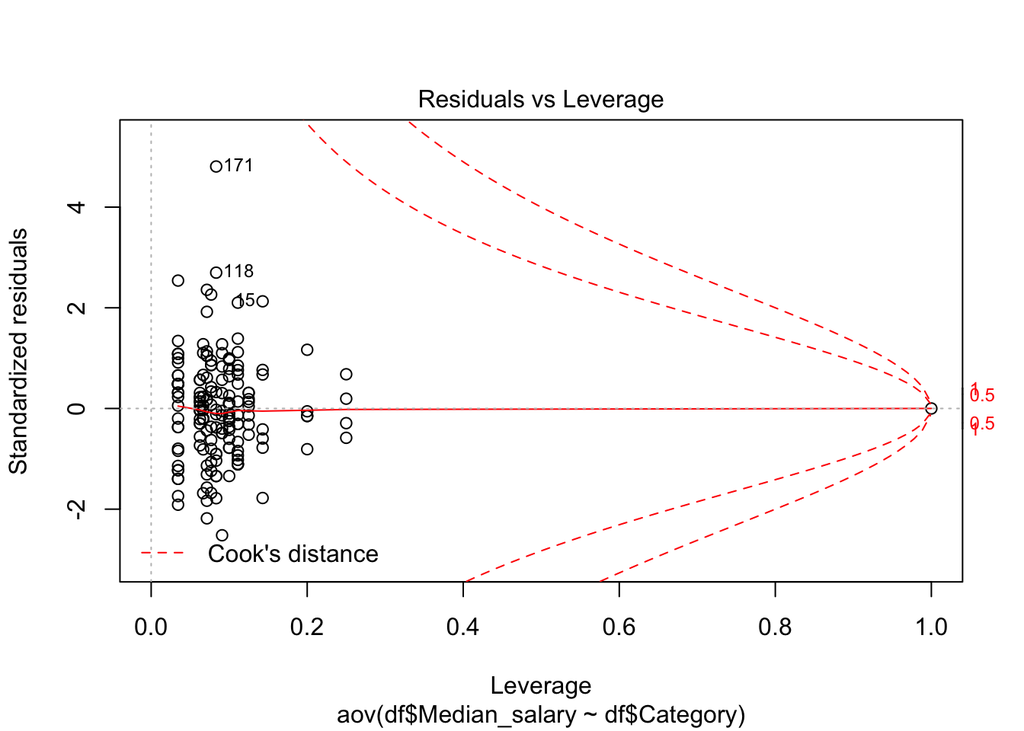

```r
plot(anova)
```

John Tukey came up with the test that bears his name when he realized the mathematical pitfalls of trying to use independent P-values to determine the utility of a multiple-variables hypothesis as a whole. At the time, t-tests were being applied to three or more groups, and he considered this dishonest – hence “honestly significant difference.”

What his test does is compare the differences between means of values rather than comparing pairs of values. The value of the Tukey test is given by taking the absolute value of the difference between pairs of means and dividing it by the standard error of the mean (SE) as determined by a one-way ANOVA test. The SE is in turn the square root of (variance divided by sample size).

The Tukey test is difficult to decipher due to testing 16 independent categories against each other. For example, this output indicates that the p-adjusted differences when small, shows that there is a significant difference of salary between those two categories. So, Business-Arts with a p-adjusted value of 0.0000800 indicates a significant difference in salary, wherelse, Arts-Interdisciplinary with a p-adjusted value of 1.0 indicates no significant difference.

```r
tukey <- TukeyHSD(anova, ordered=TRUE)
tukey
```

```
##   Tukey multiple comparisons of means
##     95% family-wise confidence level
##     factor levels have been ordered
##
## Fit: aov(formula = df$Median_salary ~ df$Category)
##
## $`df$Category`
##                                                                           diff
## Arts-Interdisciplinary                                               1543.7500
## Education-Interdisciplinary                                          3437.5000
## Psychology & Social Work-Interdisciplinary                           7455.5556
## Communications & Journalism-Interdisciplinary                        8000.0000
## Industrial Arts & Consumer Services-Interdisciplinary               11571.4286
## Humanities & Liberal Arts-Interdisciplinary                         12333.3333
## Agriculture & Natural Resources-Interdisciplinary                   14130.0000
## Social Science-Interdisciplinary                                    21444.4444
## Law & Public Policy-Interdisciplinary                               21600.0000
## Health-Interdisciplinary                                            25291.6667
## Biology & Life Science-Interdisciplinary                            28000.0000
## Business-Interdisciplinary                                          29153.8462
## Computers & Mathematics-Interdisciplinary                           30545.4545
## Physical Sciences-Interdisciplinary                                 33800.0000
## Engineering-Interdisciplinary                                       39327.5862
## Education-Arts                                                       1893.7500
## Psychology & Social Work-Arts                                        5911.8056
## Communications & Journalism-Arts                                     6456.2500
## Industrial Arts & Consumer Services-Arts                            10027.6786
## Humanities & Liberal Arts-Arts                                      10789.5833
## Agriculture & Natural Resources-Arts                                12586.2500
## Social Science-Arts                                                 19900.6944
## Law & Public Policy-Arts                                            20056.2500
## Health-Arts                                                         23747.9167
## Biology & Life Science-Arts                                         26456.2500
## Business-Arts                                                       27610.0962
## Computers & Mathematics-Arts                                        29001.7045
## Physical Sciences-Arts                                              32256.2500
## Engineering-Arts                                                    37783.8362
## Psychology & Social Work-Education                                   4018.0556
## Communications & Journalism-Education                                4562.5000
## Industrial Arts & Consumer Services-Education                        8133.9286
```

[output cut: 436 more lines]

```
## Biology & Life Science-Health                                       0.9999998
## Business-Health                                                     0.9999835
## Computers & Mathematics-Health                                      0.9995406
## Physical Sciences-Health                                            0.9510855
## Engineering-Health                                                  0.0567067
## Business-Biology & Life Science                                     1.0000000
## Computers & Mathematics-Biology & Life Science                      0.9999999
## Physical Sciences-Biology & Life Science                            0.9984192
## Engineering-Biology & Life Science                                  0.2135395
## Computers & Mathematics-Business                                    1.0000000
## Physical Sciences-Business                                          0.9999067
## Engineering-Business                                                0.4312751
## Physical Sciences-Computers & Mathematics                           0.9999995
## Engineering-Computers & Mathematics                                 0.7708418
## Engineering-Physical Sciences                                       0.9964741
```

### Part 5 - Conclusion

Our study of the American Community Survey 2010-2012 revealed how salary is distributed among educational categories. We looked at subgroups representing the categories through major types and the median salaries calculated. Our analysis included an ANOVA and Tukey testing, we were able to determine if educational categories yielded different salary results.

We can conclude this is true. Not all educational categories are created equal at least from the salary standpoint and is an important consideration for incoming freshmen. However, the most lucrative majors are not necessarily the most common. The economic value of majors plays a role in students’ choice of major, but students’ abilities, academic preparation, interests, and values are also important considerations.

### Future analysis

Measuring trends is important to determine if educational categories shift in median salaries over time. We would also look at the influences of higher education (i.e Masters, PhD), towards the scale of salary increases within categories.

### References

https://nces.ed.gov/programs/coe/indicator_cha.asp

https://cew.georgetown.edu/cew-reports/valueofcollegemajors/